# PanArctic DSL - Remote sensing

### EPSG:6931 - EASE-Grid 2.0 North (Lambert’s equal-area, azimuthal)

```r
# Empty dataframe
seaice_grid_laea <- data.frame()

# Data gridding
for (i in seq(2015, 2017, 1)) {
  seaice_tmp <- seaice_year %>%
    filter(year == i)
  # Rasterize data in latlon
  seaice_tmp_laea <- SpatialPointsDataFrame(
    SpatialPoints(cbind(seaice_tmp$xc, seaice_tmp$yc),
                  proj4string = CRS("EPSG:6931")),
    data.frame(lat = seaice_tmp$lat,
               lon = seaice_tmp$lon,
               seaice_duration = seaice_tmp$seaice_duration,
               openwater_duration = seaice_tmp$openwater_duration,
               mean_ice_conc = seaice_tmp$mean_ice_conc,
               ice_break = seaice_tmp$ice_break,
               ice_week = seaice_tmp$ice_week)) %>%
    # Rasterize data in laea
    rasterize(., arctic_laea, fun = mean, na.rm = T) %>%
    # Remove ID layer
    dropLayer(1) %>%
    # Convert raster to data frame
    rasterToPoints() %>%
    as.data.frame() %>%
    # Rename variables
    rename(xc = x, yc = y) %>%
    mutate(year = i,
           area = factor(
             case_when(lon > -155 & lon <= -95 & lat > 65 & lat <= 82 ~ "BF_CAA",
                       lon > -95 & lon <= -50 & lat > 66 & lat <= 82 ~ "BB",
                       lon >= -25 & lon <= 145 & lat > 77 & lat <= 90 ~ "SV"),
             levels = c("BF_CAA", "BB", "SV"))) %>%
    dplyr::select(year, area, lat, lon, xc, yc, seaice_duration,
                  openwater_duration, mean_ice_conc, ice_break, ice_week)
  seaice_grid_laea <- bind_rows(seaice_grid_laea, seaice_tmp_laea)
}
# Add cell resolution to dataframe
seaice_grid_laea <- seaice_grid_laea %>%
  mutate(cell_res = cell_res)
# Remove temporary data
rm(seaice_tmp, seaice_tmp_laea, i, cell_res)
```

Plot mean ice concentration and open water duration per year with the EASE-Grid 2.0 - North projection.

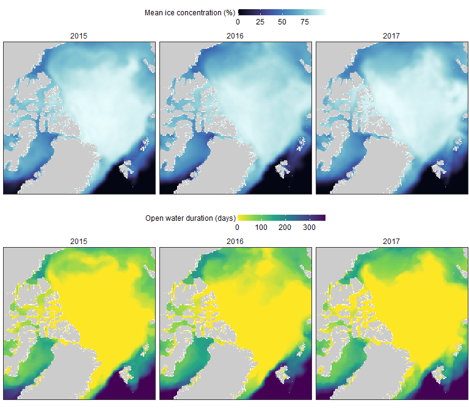

```r
# Coastline in laea
coast_10m_laea <- readOGR("data/bathy/ne_10m_land.shp", verbose = F) %>%
  spTransform(CRSobj = crs("EPSG:4326")) %>%
  crop(extent(-180, 180, 0, 90)) %>%
  spTransform(CRSobj = crs(arctic_laea)) %>%
  fortify() %>%
  rename(xc = long, yc = lat)

# Plot
plot_grid(
  # Map mean ice concentration
  seaice_grid_laea %>%
    # Remove land
    filter(is.na(mean_ice_conc) == F) %>%
    ggplot() +
    geom_tile(aes(x = xc, y = yc, fill = mean_ice_conc)) +
    scale_fill_cmocean("Mean ice concentration (%)", name = "ice") +
    geom_polygon(data = coast_10m_laea, aes(x = xc, y = yc, group = group),
                 fill = "grey80") +
    facet_wrap(~ year, ncol = 3) +
    coord_fixed(xlim = c(-2600, 1100), ylim = c(-1800, 1900), expand = F) +
    theme(legend.position = "top",
          legend.key.height = unit(0.1, "in"),
          legend.key.width = unit(0.3, "in"),
          axis.text = element_blank(),
          axis.ticks = element_blank(),
          axis.title = element_blank()),
  # Map openwater duration
  seaice_grid_laea %>%
    # Remove land
    filter(is.na(mean_ice_conc) == F) %>%
    ggplot() +
    geom_tile(aes(x = xc, y = yc, fill = openwater_duration)) +
    scale_fill_viridis_c("Open water duration (days)", direction = -1) +
    geom_polygon(data = coast_10m_laea, aes(x = xc, y = yc, group = group), fill =
                   "grey80") +
    facet_wrap(~ year, ncol = 3) +
    coord_fixed(xlim = c(-2600, 1100), ylim = c(-1800, 1900), expand = F) +
    theme(legend.position = "top",
          legend.key.height = unit(0.1, "in"),
          legend.key.width = unit(0.3, "in"),
          axis.text = element_blank(),
          axis.ticks = element_blank(),
          axis.title = element_blank()),
  ncol = 1, align = "hv", axis = "tblr")
```

# Arctic Ocean Physics Reanalysis

The [Arctic Ocean Physics Reanalysis](https://resources.marine.copernicus.eu/product-detail/ARCTIC_MULTIYEAR_PHY_002_003/INFORMATION) dataset was downloaded using a Jupyter notebook. The dataset has a 12.5 km<sup>2</sup> grid resolution and a specific polar stereographic projection. Because PROJ4 strings are not have been replaced by WKT2 strings in `rgdal`, I need to convert the PROJ4 custom projection of Copernicus into a WKT2 string. I need to verify if the `st_crs` function converts the proj4 string into a WKT2 string correctly. Data is downloaded at 0, 222, 266, 318, 380, 644, 1062 m depth.

The variables are:

- thetao: Temperature degree Celsius
- so: Salinity psu
- vxo: Zonal velocity m/s (x)
- vyo: Meridional velocity m/s (y)
- x: x-coordinate (not longitude, need to be reprojected)
- y: y-coordinate (not latitude, need to be reprojected)
- mlotst: mixed layer thickness (m)
- siconc: sea ice concentration (1)
- sithick: sea ice thickness (m)
- depth: depth in meters
- time: time in hours since 1950-01-01 00:00:00
- latitude: latitude
- longitude: longitude

## Exploratory code

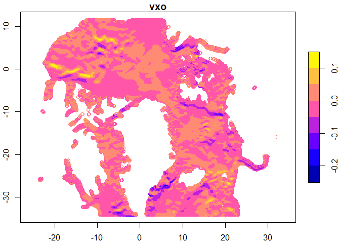

```r
# Read sea ice data and mixed layer depth
test_ice <- tidync("data/remote_sensing/physics/20150115_222m_phy_CMEMS.nc") %>%
  activate("D0,D1,D2") %>%
  hyper_tibble()
# Read temperature, salinity, and current velocity
test_oce <- tidync("data/remote_sensing/physics/20150115_222m_phy_CMEMS.nc") %>%
  activate("D0,D1,D3,D2") %>% # D0 = x, D1 = y, D3 = depth, D2 = time
  hyper_tibble()
# Read sea ice data and mixed layer depth
test_meta <- tidync("data/remote_sensing/physics/20150115_222m_phy_CMEMS.nc") %>%
  activate("D0,D1") %>%
  hyper_tibble()

# Combine data
test <- left_join(test_ice, test_oce, by = c("x", "y", "time")) %>%
  left_join(., test_meta, by = c("x", "y")) %>%
  # Remove data from land or below seafloor
  filter(is.na(depth) == F) %>%
  # Calculate date
  mutate(date = as.POSIXct(time * 3600,
                           origin = "1950-01-01 00:00:00",
                           tz = "UTC")) %>%
  rename(lat = latitude, lon = longitude) %>%
  dplyr::select(-time)

# Define projection
proj_original <- "+proj=stere +a=6378273.0 +b=6378273.0 +lon_0=-45.0 +lat_0=90.0 +lat_ts=90.0 +ellps=sphere +units=m"

# Convert dataframe to sf
test_sf <- st_as_sf(test, coords = c("x", "y"), crs = proj_original)
plot(test_sf["vxo"], axes = TRUE)
```

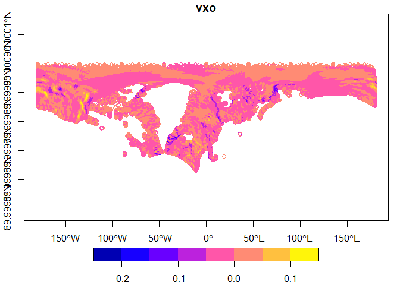

```r
# Convert dataframe to sf
test_sf2 <- st_as_sf(test, coords = c("x", "y"), crs = proj_original) %>%
  # Transform to EPSG:4326
  st_transform(., crs = "EPSG:4326")
# Not working
plot(test_sf2["vxo"], axes = TRUE)
```

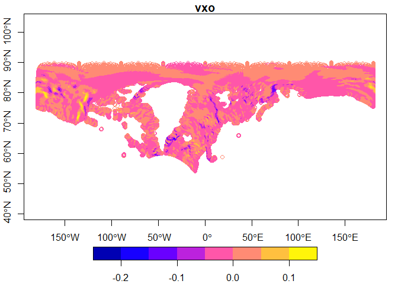

```r
# Convert dataframe to sf with correct CRS
test_sf3 <- st_as_sf(test, coords = c("lon", "lat"), crs = "EPSG:4326")
# Working!
plot(test_sf3["vxo"], axes = TRUE)
```

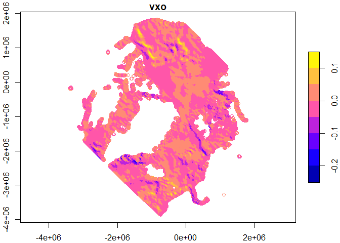

```r
# Convert dataframe to sf with correct CRS
test_sf4 <- st_as_sf(test, coords = c("lon", "lat"), crs = "EPSG:4326") %>%
  # Convert to EPSG:6931
  st_transform(., crs = "EPSG:6931")
# Working
plot(test_sf4["vxo"], axes = TRUE)
```

```r
# Remove temporary data
rm(test_ice, test_meta, test_oce, test_sf, test_sf2, test_sf3, test_sf4, test)
```

## Batch processing

Batch processing of Arctic Ocean Physics Reanalysis data. For convenience, all NetCDF data is combined per year and saved as csv. Since I downloaded physics data in two batches—0, 222, 380, 644, 1062 m depth and 266 and 318 m depth, I split the tidying into two chunks.

```r
# Loop through data per year
for (y in seq(2015, 2017, 1)) {
  # Empty dataframe
  phy_year <-  data.frame()
  # List files per year
  file_list <- list.files("data/remote_sensing/physics",
                          pattern = paste0(y),
                          full.names = T)
  # Loop through each file
  for (i in file_list) {
    # Read NetCDF
    phy_ice_tmp <- tidync(i) %>%
      # sea ice data and mixed layer depth
      activate("D0,D1,D2") %>%
      hyper_tibble()
    phy_oce_tmp <- tidync(i) %>%
      # temperature, salinity, depth, and current velocity
      activate("D0,D1,D3,D2") %>%
      hyper_tibble()
    phy_coord_tmp <- tidync(i) %>%
      # latitude and longitude
      activate("D0,D1") %>%
      hyper_tibble()
    # Combine datasets
    phy_tmp <- left_join(phy_ice_tmp, phy_oce_tmp, by = c("x", "y", "time")) %>%
      left_join(., phy_coord_tmp, by = c("x", "y")) %>%
      # Remove data from land or below seafloor
      filter(is.na(depth) == F) %>%
      # Calculate date
      mutate(date = as.POSIXct(time * 3600,
                               origin = "1950-01-01 00:00:00",
                               tz = "UTC")) %>%
      rename(lat = latitude, lon = longitude)
    # Append data together
    phy_year <- bind_rows(phy_year, phy_tmp)
  }
  # Write one csv per year
  write_csv(phy_year,
            file = paste0("data/remote_sensing/physics/physics_reanalysis_",
                          y, ".csv"))
  print(paste0("Processing of ", y, " data finished."))
}
# Remove temprorary data
rm(phy_coord_tmp, phy_ice_tmp, phy_oce_tmp, phy_tmp, phy_year)
```

```r
# Loop through data per year
for (y in seq(2015, 2017, 1)) {
  # Empty dataframe
  phy_year <-  data.frame()
  # List files per year
  file_list <- list.files("data/remote_sensing/physics/phy_266_318m",
                          pattern = paste0(y),
                          full.names = T)
  # Loop through each file
  for (i in file_list) {
    # Read NetCDF
    phy_ice_tmp <- tidync(i) %>%
      # sea ice data and mixed layer depth
      activate("D0,D1,D2") %>%
      hyper_tibble()
    phy_oce_tmp <- tidync(i) %>%
      # temperature, salinity, depth, and velocity
      activate("D0,D1,D3,D2") %>%
      hyper_tibble()
    phy_coord_tmp <- tidync(i) %>%
      # latitude and longitude
      activate("D0,D1") %>%
      hyper_tibble()
    # Combine datasets
    phy_tmp <- left_join(phy_ice_tmp, phy_oce_tmp, by = c("x", "y", "time")) %>%
      left_join(., phy_coord_tmp, by = c("x", "y")) %>%
      # Remove data from land or below seafloor
      filter(is.na(depth) == F) %>%
      # Calculate date
      mutate(date = as.POSIXct(time * 3600,
                               origin = "1950-01-01 00:00:00",
                               tz = "UTC")) %>%
      rename(lat = latitude, lon = longitude)
    # Append data together
    phy_year <- bind_rows(phy_year, phy_tmp)
  }
  # Write one csv per year
  write_csv(
    phy_year,
    file = paste0("data/remote_sensing/physics/physics_reanalysis_266_318m_",
                  y, ".csv"))
  print(paste0("Processing of ", y, " data finished."))
}
# Remove temporary data
rm(phy_coord_tmp, phy_ice_tmp, phy_oce_tmp, phy_tmp, phy_year)
```

Tidy csv data and calculate current velocity and angle. I also calculate the annual average of each variable. The annual average dataset will be used for comparison with acoustic data.

```r
# List files
phy_year <- list.files("data/remote_sensing/physics",
                  pattern = "*.csv",
                  full.names = T) %>%
  # Read files
  map_dfr(.f = ~ read_csv(., show_col_types = F)) %>%
  lazy_dt() %>%
  mutate(year = year(date),
         month = month(date),
         # Current velocity
         velocity = sqrt(vxo ^ 2 + vyo ^ 2),
         # Current direction
         v_angle = atan(vyo / vxo) * (180 / pi)) %>%
  arrange(year, date, depth) %>%
  dplyr::select(- date, - month) %>%
  # Group by cell by year by depth
  group_by(year, x, y, depth) %>%
  # Calculate annual average for each variable
  summarise_all(mean) %>%
  ungroup() %>%
  as_tibble()
```

Plot average current velocity in 2015 in Svalbard at 318 m depth.

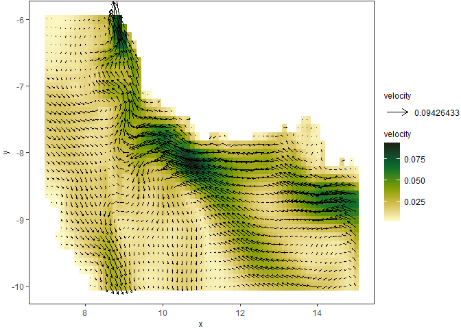

```r
phy_year %>%
  filter(year == 2015 & depth == 318 & between(x, 7, 15) & between(y, -10, -6)) %>%
  ggplot() +
  geom_raster(aes(x = x, y = y, fill = velocity)) +
  geom_vector(aes(x = x, y = y, dx = vxo, dy = vyo, mag = velocity),
              arrow.angle = 30, arrow.type = "open", arrow.length = .5,
              pivot = 0, preserve.dir = TRUE, direction = "ccw") +
  scale_fill_cmocean(name = "speed") +
  coord_cartesian()
```

### EPSG:6931 - EASE-Grid 2.0 North (Lambert’s equal-area, azimuthal)

```r
# Projection, cell resolution in km
cell_res <- 12.5
arctic_laea <- raster(extent(-2700, 2700, -2700, 2700), crs = "EPSG:6931")
projection(arctic_laea) <- gsub("units=m", "units=km", projection(arctic_laea))
res(arctic_laea) <- c(cell_res, cell_res)

# Empty dataframe
phy_grid_laea <- data.frame()

# Loop through each year
for (i in seq(2015, 2017, 1)) {
  # Loop through each depth bin
  for (j in c(0, 222, 266, 318, 380, 644, 1062)) {
    phy_year_tmp <- phy_year %>%
      # Select depth bin
      filter(year == i & depth == j)
    # Rasterize data in laea
    phy_tmp_laea <- SpatialPointsDataFrame(
      SpatialPoints(cbind(phy_year_tmp$lon, phy_year_tmp$lat),
                    proj4string = CRS("EPSG:4326")),
      data.frame(lat = phy_year_tmp$lat,
                 lon = phy_year_tmp$lon,
                 depth = phy_year_tmp$depth,
                 mlotst = phy_year_tmp$mlotst,
                 siconc = phy_year_tmp$siconc,
                 sithick = phy_year_tmp$sithick,
                 thetao = phy_year_tmp$thetao,
                 so = phy_year_tmp$so,
                 velocity = phy_year_tmp$velocity,
                 vxo = phy_year_tmp$vxo,
                 vyo = phy_year_tmp$vyo)) %>%
      # Change projection to EPSG:6931
      spTransform(., CRSobj = crs(arctic_laea)) %>%
      # Rasterize
      rasterize(., arctic_laea, fun = mean, na.rm = T) %>%
      # Remove ID layer
      dropLayer(1) %>%
      # Convert raster to data frame
      rasterToPoints() %>%
      as.data.frame() %>%
      # Rename variables
      rename(xc = x, yc = y) %>%
      mutate(year = i,
             depth = j,
             area = factor(
               case_when(lon > -155 & lon <= -95 & lat > 65 & lat <= 82 ~ "BF_CAA",
                         lon > -95 & lon <= -50 & lat > 66 & lat <= 82 ~ "BB",
                         lon >= -25 & lon <= 145 & lat > 77 & lat <= 90 ~ "SV"),
               levels = c("BF_CAA", "BB", "SV"))) %>%
      dplyr::select(year, area, lat, lon, xc, yc, depth, mlotst, siconc, sithick,
                    thetao, so, velocity, vxo, vyo)
    # Combine data
    phy_grid_laea <- bind_rows(phy_grid_laea, phy_tmp_laea)
  }
}

# Add cell resolution
phy_grid_laea <- phy_grid_laea %>%
  mutate(cell_res = cell_res)

# Remove temporary data
rm(phy_year_tmp, phy_tmp_laea, i, j)
```

Gridding worked correctly, the following plot shows current velocity at all depth levels.

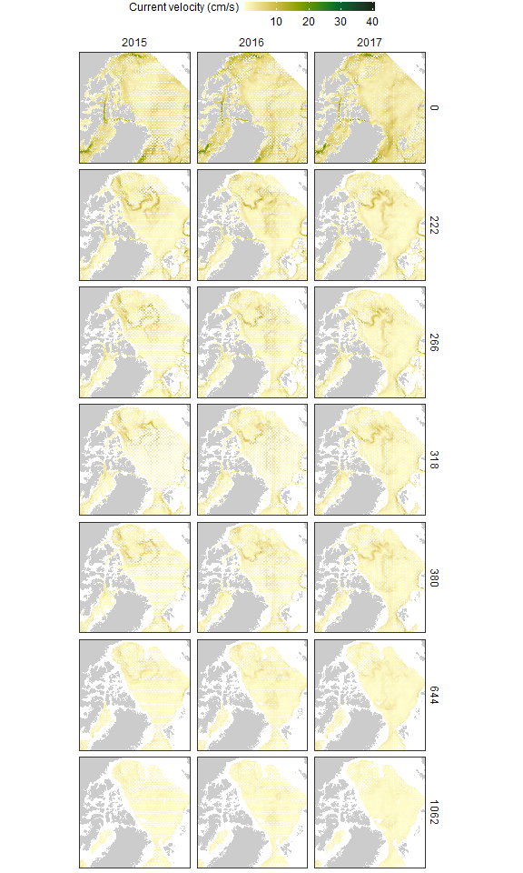

```r
coast_10m_laea <- readOGR("data/bathy/ne_10m_land.shp", verbose = F) %>%
  spTransform(CRSobj = crs("EPSG:4326")) %>%
  crop(extent(-180, 180, 0, 90)) %>% # Crop shapefile
  spTransform(CRSobj = crs(arctic_laea)) %>% # Project shapefile in laea
  fortify() %>% # Convert to a dataframe for ggplot
  rename(xc = long, yc = lat)

phy_grid_laea %>%
  ggplot() +
  geom_tile(aes(x = xc, y = yc, fill = velocity * 100)) +
  scale_fill_cmocean("Current velocity (cm/s)", name = "speed") +
  geom_polygon(data = coast_10m_laea, aes(x = xc, y = yc, group = group),
               fill = "grey80") +
  facet_grid(depth ~ year) +
  coord_fixed(xlim = c(-2600, 1100), ylim = c(-1800, 1900), expand = F) +
  theme(legend.position = "top",
        legend.key.height = unit(0.1, "in"),
        legend.key.width = unit(0.3, "in"),
        axis.text = element_blank(),
        axis.ticks = element_blank(),
        axis.title = element_blank())
```

# Ocean colour data

Data downloaded from Copernicus Marine. The ocean colour data comes from the [OCEANCOLOUR_ARC_CHL_L4_REP_OBSERVATIONS_009_088](https://resources.marine.copernicus.eu/product-detail/OCEANCOLOUR_ARC_CHL_L4_REP_OBSERVATIONS_009_088/INFORMATION) dataset. Data is monthly averaged and has a cell resolution of 1 x 1 km on a WGS 84 / Plate Carree (EPSG:32662) projection.

```r
# Sea ice projection
cell_res <- 12.5
arctic_laea <- raster(extent(-2700, 2700, -2700, 2700), crs = "EPSG:6931")
projection(arctic_laea) <- gsub("units=m", "units=km", projection(arctic_laea))
res(arctic_laea) <- c(cell_res, cell_res)

# List files
file_list <- list.files("data/remote_sensing/ocean_colour/nc",
                        pattern = ".nc", full.names = T)
# Loop through each file per year
for (i in file_list) {
  # Extract date
  date_file <- str_remove(i, pattern = "data/remote_sensing/ocean_colour/nc/") %>%
    str_remove(., pattern = "_chl_CMEMS.nc")
  # Chlorophyll data
  chl_tmp <- tidync(i) %>%
    activate("D2,D1,D0") %>%
    hyper_tibble() %>%
    rename(lat = latitude, lon = longitude, chl = CHL)

  # If data is not empty then rasterize
  if (nrow(chl_tmp > 0)){
    # Rasterize data in laea
    chl_tmp_laea <- SpatialPointsDataFrame(
      SpatialPoints(cbind(chl_tmp$lon, chl_tmp$lat),
                    proj4string = CRS("EPSG:4326")),
      data.frame(lat = chl_tmp$lat,
                 lon = chl_tmp$lon,
                 time = chl_tmp$time,
                 chl = chl_tmp$chl)) %>%
      # Project to EPSG:6931
      spTransform(., CRSobj = crs(arctic_laea)) %>%
      # Rasterize on the arctic_laea grid (with correct grid resolution)
      rasterize(., arctic_laea, fun = mean, na.rm = T) %>%
      # Remove ID layer
      dropLayer(1) %>%
      # Convert raster to data frame
      rasterToPoints() %>%
      as.data.frame() %>%
      # Rename variables
      rename(xc = x, yc = y) %>%
      # Tidy data
      mutate(date = as.POSIXct(time , origin = "1970-01-01 00:00:00", tz = "UTC"),
             year = year(date),
             cell_res = cell_res)
    # Write csv
    write_csv(chl_tmp_laea,
              file = paste0("data/remote_sensing/ocean_colour/ocean_colour_",
                            date_file, "_", cell_res, "km.csv"))
    print(paste0("Processing of ", date_file, " chl data finished."))
    # Remove temporary file
    rm(chl_tmp_laea)
  }
  # Else move on to next file
  else {
    print(paste0("No chl data for ", date_file, ". Moving to next file."))
  }
  # Remove temporary variables
  rm(chl_tmp)
}
```

```
## [1] "No chl data for 20150101. Moving to next file."
## [1] "Processing of 20150201 chl data finished."
## [1] "Processing of 20150301 chl data finished."
## [1] "Processing of 20150401 chl data finished."
## [1] "Processing of 20150501 chl data finished."
## [1] "Processing of 20150601 chl data finished."
## [1] "Processing of 20150701 chl data finished."
## [1] "Processing of 20150801 chl data finished."
## [1] "Processing of 20150901 chl data finished."
## [1] "Processing of 20151001 chl data finished."
## [1] "No chl data for 20151101. Moving to next file."
## [1] "No chl data for 20151201. Moving to next file."
## [1] "No chl data for 20160101. Moving to next file."
## [1] "Processing of 20160201 chl data finished."
## [1] "Processing of 20160301 chl data finished."
```

[output cut: 21 more lines]

```r
# Remove temporary variables
rm(date_file, i, file_list)
```

After rasterizing data I reload the csv files and combine the monthly data into a single dataframe. Then, I calculate the average annual concentration of chl a per cell.

```r
# List files
chl_grid_laea <- list.files("data/remote_sensing/ocean_colour",
                            pattern = "*.csv",
                            full.names = T) %>%
  # Read files
  map_dfr(.f = ~ read_csv(., show_col_types = F)) %>%
  mutate(area = factor(
    case_when(lon > -155 & lon <= -95 & lat > 65 & lat <= 82 ~ "BF_CAA",
              lon > -95 & lon <= -50 & lat > 66 & lat <= 82 ~ "BB",
              lon >= -25 & lon <= 145 & lat > 77 & lat <= 90 ~ "SV"),
    levels = c("BF_CAA", "BB", "SV"))) %>%
  group_by(year, area, xc, yc, cell_res) %>%
  summarise(chl = mean(chl)) %>%
  ungroup()
```

# Save data

```r
# Save data
save(seaice_grid_laea,
     file = paste0("data/remote_sensing/seaice_grids_", cell_res, "km.RData"))
save(phy_grid_laea,
     file = paste0("data/remote_sensing/physics_grids_", cell_res, "km.RData"))
save(chl_grid_laea,
     file = paste0("data/remote_sensing/chl_grids_", cell_res, "km.RData"))
```